# Working with HDF5-Backed Matrices in BigDataStatMeth

Dolors Pelegri-Siso and Juan R. Gonzalez

Universitat Autonoma de Barcelona (UAB)  
ISGlobal, Centre for Research in Environmental Epidemiology (ISGlobal)  
Bioinformatics Research Group in Epidemiology (BRGE)

dolors.pelegri@isglobal.org  
juanr.gonzalez@isglobal.org

2026-09-16

#### Abstract

This vignette illustrates how to work with HDF5-backed matrices using the S3 interface provided by the BigDataStatMeth package. It covers matrix creation, data import, subsetting, algebraic and statistical operations, matrix decompositions, global options, compression, HDF5 file-space management, and resource handling.

# 1 Overview

`BigDataStatMeth` provides statistical and linear algebra operations for matrices stored in HDF5 files. The package is designed for workflows in which matrices may be too large to be held entirely in memory, while still allowing users to work with familiar R functions.

The examples in this vignette use small matrices so that they can be run quickly and compared with standard in-memory R results. The same interface is intended for larger HDF5-backed matrices. All files created in the examples are written to temporary locations.

```r
library(BigDataStatMeth)
```

# 2 User-facing interface and global options

The recommended user-facing interface is based on `HDF5Matrix` objects and standard R generics. Thus, HDF5-backed matrices can be manipulated using calls such as `dim()`, `[`, `%*%`, `crossprod()`, `scale()`, `cor()`, `svd()`, `qr()`, and `prcomp()`.

Internally, `BigDataStatMeth` uses an R6 and C++ backend. Advanced users may interact with lower-level interfaces when needed, but this vignette focuses on the S3 interface because it allows code to remain close to ordinary R matrix workflows.

The following table summarizes the main user-facing functionality available for `HDF5Matrix` objects. It is not an exhaustive list of all exported functions; rather, it highlights the standard R-style methods and high-level helpers used throughout this vignette. Additional domain-specific, lower-level, and compatibility functions are documented in their corresponding help pages.

| Category | Representative calls |
| --- | --- |
| Core object handling | `hdf5_create_matrix()`, `hdf5_matrix()`, `dim()`, `nrow()`, `ncol()`, `is_open()`, `close()` |
| HDF5 inspection and I/O | `list_datasets()`, `hdf5_import()`, `hdf5_import_multiple()`, `as.matrix()`, `as.data.frame()` |
| Subsetting and assignment | `X[i, j]`, `X[i, j] <- value` |
| Dimension names | `rownames()`, `colnames()`, `dimnames()` |
| Element-wise arithmetic | `X + Y`, `X - Y`, `X * Y`, `X / Y` |
| Matrix algebra | `%*%`, `crossprod()`, `tcrossprod()` |
| Binding | `cbind()`, `rbind()` |
| Aggregations | `colSums()`, `rowSums()`, `colMeans()`, `rowMeans()`, `colVars()`, `rowVars()`, `colSds()`, `rowSds()`, `colMins()`, `rowMins()`, `colMaxs()`, `rowMaxs()` |
| Scalar summaries | `mean()`, `var()`, `sd()` |
| Normalization and transformations | `scale()`, `sweep()` |
| Correlation | `cor()` |
| Matrix decompositions | `svd()`, `prcomp()`, `eigen()`, `pseudoinverse()` |
| Factorizations and solvers | `qr()`, `chol()`, `solve()` |
| Diagonal operations | `diag()`, `diag<-()`, `diag_op()`, `diag_scale()` |
| Split, reduce, and apply | `split()`, `split_dataset()`, `reduce()`, `hdf5_reduce()`, `apply_function()`, `hdf5_apply()` |
| Resource management and options | `hdf5matrix_options()`, `show_hdf5matrix_options()`, `hdf5_close_all()` |
| Specialized high-level helpers | selected `bd*` functions for utilities without a direct standard R generic, such as `bdCreate_hdf5_group()`, `bdmove_hdf5_dataset()`, and `bdWrite_hdf5_dimnames()` |

Most examples in this vignette use the standard `HDF5Matrix`/S3 interface. Some high-level helper functions keep the `bd*` prefix because they provide specialized functionality that does not map directly to an existing base R generic. These functions remain part of the package API and are documented in their corresponding help pages.

## 2.1 Global options

Some S3 operators, such as element-wise arithmetic, follow the standard R syntax and do not expose additional arguments in the function call. Global options make it possible to configure block-wise processing, parallelization, the number of threads, and compression for such operations.

```r
old_opts <- hdf5matrix_options()
old_opts
$paral
NULL

$block_size
NULL

$threads
NULL

$compression
NULL
```

For example, the following settings enable parallel execution with two threads, use a fixed block size, and set the compression level used for new output datasets when not explicitly specified by a method call.

```r
hdf5matrix_options(
  paral = TRUE,
  threads = 2L,
  block_size = 512L,
  compression = 6L
)

hdf5matrix_options()
$paral
[1] TRUE

$block_size
[1] 512

$threads
[1] 2

$compression
[1] 6
```

When an individual method provides explicit arguments, those arguments should be used for local control of that operation. The global options are especially useful for generic operators where the standard R call is kept unchanged. Additional operation-specific parameters are documented in the corresponding help pages, for example `?svd.HDF5Matrix`, `?prcomp.HDF5Matrix`, `?qr.HDF5Matrix`, and `?hdf5matrix_options`.

# 3 Creating, opening, and inspecting HDF5 datasets

The function `hdf5_create_matrix()` creates an HDF5 dataset and returns an `HDF5Matrix` object pointing to it. In the example below, a standard R matrix is written to an HDF5 file and then manipulated through the S3 interface.

```r
h5file <- tempfile(fileext = ".h5")

set.seed(123)
X <- matrix(rnorm(500 * 100), nrow = 500, ncol = 100)

X_h5 <- hdf5_create_matrix(
  filename = h5file,
  dataset = "data/X",
  data = X,
  overwrite = TRUE
)

X_h5
HDF5Matrix object
  File: /var/folders/qf/1vjbzhlx1lv7nsddk8ky3p_r0000gn/T//RtmpSLgd7T/file58782877a77b.h5
  Path: data/X
  Dimensions: 500 x 100
  Type:
  Status: OPEN
dim(X_h5)
[1] 500 100
nrow(X_h5)
[1] 500
ncol(X_h5)
[1] 100
```

The datasets stored in an HDF5 file can be listed with `list_datasets()`. Existing datasets can be reopened with `hdf5_matrix()`.

```r
list_datasets(h5file)
[1] "data/X"

X_h5_reopened <- hdf5_matrix(
  filename = h5file,
  path = "data/X"
)

dim(X_h5_reopened)
[1] 500 100
```

Operations that return an `HDF5Matrix` object write their results to an HDF5 dataset. The printed object shows the file and dataset path. Some methods, such as `crossprod()` and `tcrossprod()`, allow the output group and dataset name to be specified explicitly. Other S3 operators, such as element-wise arithmetic, currently use package-defined output names.

# 4 Importing tabular data

```r
# Generate reproducible example data matching the cholesterol dataset structure
set.seed(4214123)
n <- 1000L

colesterol <- data.frame(
  TCholesterol = rnorm(n, mean = 195.8, sd = 30.1),
  Age          = rnorm(n, mean = 58.4,  sd = 9.9),
  Insulin      = rnorm(n, mean = 12.5,  sd = 7.4),
  Creatinine   = rnorm(n, mean = 0.798, sd = 0.098),
  BUN          = rnorm(n, mean = 14.6,  sd = 3.4),
  LLDR         = rnorm(n, mean = 0.981, sd = 0.450),
  Triglycerides= rnorm(n, mean = 136.6, sd = 55.1),
  HDL_C        = rnorm(n, mean = 48.2,  sd = 9.2),
  LDL_C        = rnorm(n, mean = 116.4, sd = 25.5),
  Sex          = rbinom(n, 1, prob = 0.58)
)

csv_file <- tempfile(fileext = ".csv")
write.csv(colesterol, csv_file, row.names = FALSE)

h5_csv <- tempfile(fileext = ".h5")

cholesterol_h5 <- hdf5_import(
  source = csv_file,
  filename = h5_csv,
  dataset = "cholesterol/data",
  sep = ",",
  header = TRUE,
  overwrite = TRUE
)

cholesterol_h5
HDF5Matrix object
  File: /var/folders/qf/1vjbzhlx1lv7nsddk8ky3p_r0000gn/T//RtmpSLgd7T/file58786bd7ed81.h5
  Path: cholesterol/data
  Dimensions: 1000 x 10
  Type:
  Status: OPEN
dim(cholesterol_h5)
[1] 1000   10
cholesterol_h5[1:5, 1:min(6, ncol(cholesterol_h5))]
     TCholesterol      Age   Insulin Creatinine       BUN      LLDR
[1,]     210.6167 71.49745  2.109771  0.7787582 15.315296 0.7306967
[2,]     231.8875 53.95919 15.652611  0.8264965  9.401774 1.2230963
[3,]     191.7023 56.31360  7.744493  0.9293400  5.071212 1.2897677
[4,]     214.3665 45.09847 22.989093  0.8592065 14.564008 0.8122450
[5,]     202.0006 39.70275 11.293069  0.7682224 18.492814 1.0190207
```

# 5 Subsetting, assignment, dimnames, and conversion to memory

The `[` operator can be used to read subsets from an `HDF5Matrix` object. Only the requested rows and columns are read.

```r
X_h5[1:5, 1:6]
            [,1]       [,2]        [,3]       [,4]       [,5]       [,6]
[1,] -0.56047565 -0.6018928 -0.99579872 -0.8209867 -0.5116037 -0.6788076
[2,] -0.23017749 -0.9936986 -1.03995504 -0.3072572  0.2369379  0.5743127
[3,]  1.55870831  1.0267851 -0.01798024 -0.9020980 -0.5415892 -0.7045145
[4,]  0.07050839  0.7510613 -0.13217513  0.6270687  1.2192276 -0.5339841
[5,]  0.12928774 -1.5091665 -2.54934277  1.1203550  0.1741359  0.7743846

sub_X <- X_h5[1:20, 1:10]
dim(sub_X)
[1] 20 10
```

The replacement form `[<-` writes values back to the HDF5 dataset. Changes are applied directly to the data stored on disk.

```r
X_edit <- hdf5_create_matrix(
  h5file,
  "data/X_edit",
  data = X[1:10, 1:6],
  overwrite = TRUE
)

X_edit[1, 1] <- 999
X_edit[1:3, 1:3]
            [,1]       [,2]        [,3]
[1,] 999.0000000 -0.6018928 -0.99579872
[2,]  -0.2301775 -0.9936986 -1.03995504
[3,]   1.5587083  1.0267851 -0.01798024
```

Dimension names can also be stored and retrieved with the usual R accessors.

```r
DN_h5 <- hdf5_create_matrix(
  h5file,
  "data/dimnames_example",
  data = matrix(seq_len(12), nrow = 4, ncol = 3),
  overwrite = TRUE
)

rownames(DN_h5) <- paste0("sample_", seq_len(nrow(DN_h5)))
colnames(DN_h5) <- paste0("feature_", seq_len(ncol(DN_h5)))

rownames(DN_h5)
[1] "sample_1" "sample_2" "sample_3" "sample_4"
colnames(DN_h5)
[1] "feature_1" "feature_2" "feature_3"
dimnames(DN_h5)
[[1]]
[1] "sample_1" "sample_2" "sample_3" "sample_4"

[[2]]
[1] "feature_1" "feature_2" "feature_3"
```

The function `as.matrix()` reads an HDF5-backed matrix into memory. It is useful for small examples or final results, but should be used with care for very large datasets.

```r
X_small <- as.matrix(X_h5[1:10, 1:5])
X_small
             [,1]        [,2]        [,3]       [,4]       [,5]
 [1,] -0.56047565 -0.60189285 -0.99579872 -0.8209867 -0.5116037
 [2,] -0.23017749 -0.99369859 -1.03995504 -0.3072572  0.2369379
 [3,]  1.55870831  1.02678506 -0.01798024 -0.9020980 -0.5415892
 [4,]  0.07050839  0.75106130 -0.13217513  0.6270687  1.2192276
 [5,]  0.12928774 -1.50916654 -2.54934277  1.1203550  0.1741359
 [6,]  1.71506499 -0.09514745  1.04057346  2.1272136 -0.6152683
 [7,]  0.46091621 -0.89594782  0.24972574  0.3661144 -1.8068930
 [8,] -1.26506123 -2.07075107  2.41620737 -0.8747814 -0.6436811
 [9,] -0.68685285  0.15012013  0.68519824  1.0244749  2.0460189
[10,] -0.44566197 -0.07921171 -0.44695931  0.9047589 -0.5607624
```

# 6 Matrix algebra

## 6.1 Element-wise arithmetic

Element-wise arithmetic between `HDF5Matrix` objects can be performed using the standard arithmetic operators. The results are stored as new HDF5-backed matrices.

```r
set.seed(1)

A <- matrix(rnorm(300 * 80), nrow = 300, ncol = 80)
B <- matrix(rnorm(300 * 80), nrow = 300, ncol = 80)
C <- matrix(rnorm(80 * 40), nrow = 80, ncol = 40)

A_h5 <- hdf5_create_matrix(
  h5file, "data/A", data = A,
  overwrite = TRUE
)

B_h5 <- hdf5_create_matrix(
  h5file, "data/B", data = B,
  overwrite = TRUE
)

C_h5 <- hdf5_create_matrix(
  h5file, "data/C", data = C,
  overwrite = TRUE
)

S_h5 <- A_h5 + B_h5
D_h5 <- A_h5 - B_h5

S_h5
HDF5Matrix object
  File: /var/folders/qf/1vjbzhlx1lv7nsddk8ky3p_r0000gn/T//RtmpSLgd7T/file58782877a77b.h5
  Path: OUTPUT/A_plus_B
  Dimensions: 300 x 80
  Type:
  Status: OPEN
dim(S_h5)
[1] 300  80

all.equal(as.matrix(S_h5), A + B)
[1] TRUE
all.equal(as.matrix(D_h5), A - B)
[1] TRUE
```

The output datasets can be inspected directly from the file. This is useful when results need to be reopened later in the workflow.

```r
list_datasets(h5file, group = "OUTPUT", recursive = TRUE)
[1] "A_minus_B" "A_plus_B"
```

## 6.2 Matrix multiplication

Matrix multiplication uses the same `%*%` syntax as ordinary R matrices, while the computation is performed block-wise on the HDF5-backed data.

```r
M_h5 <- A_h5 %*% C_h5

M_h5
HDF5Matrix object
  File: /var/folders/qf/1vjbzhlx1lv7nsddk8ky3p_r0000gn/T//RtmpSLgd7T/file58782877a77b.h5
  Path: OUTPUT/A_x_C
  Dimensions: 300 x 40
  Type:
  Status: OPEN
dim(M_h5)
[1] 300  40
all.equal(as.matrix(M_h5), A %*% C)
[1] TRUE
```

## 6.3 Crossproducts

Crossproducts are available through the standard R calls. These methods also allow the output group and dataset name to be specified explicitly.

```r
XtX_h5 <- crossprod(
  A_h5,
  outgroup = "RESULTS",
  outdataset = "A_crossprod"
)

XXt_h5 <- tcrossprod(
  A_h5,
  outgroup = "RESULTS",
  outdataset = "A_tcrossprod"
)

XtX_h5
HDF5Matrix object
  File: /var/folders/qf/1vjbzhlx1lv7nsddk8ky3p_r0000gn/T//RtmpSLgd7T/file58782877a77b.h5
  Path: RESULTS/A_crossprod
  Dimensions: 80 x 80
  Type:
  Status: OPEN
list_datasets(h5file, group = "RESULTS", recursive = TRUE)
[1] "A_crossprod"  "A_tcrossprod"

all.equal(as.matrix(XtX_h5), crossprod(A))
[1] TRUE
all.equal(as.matrix(XXt_h5), tcrossprod(A))
[1] TRUE
```

## 6.4 Binding matrices

The functions `cbind()` and `rbind()` can be used to combine compatible HDF5-backed matrices by columns or rows.

```r
A1_h5 <- hdf5_create_matrix(
  h5file,
  "bind/A1",
  data = A[1:50, 1:10],
  overwrite = TRUE
)

A2_h5 <- hdf5_create_matrix(
  h5file,
  "bind/A2",
  data = A[1:50, 11:20],
  overwrite = TRUE
)

Cbind_h5 <- cbind(
  A1_h5, A2_h5,
  out_group = "BIND_RESULTS",
  out_dataset = "A1_A2_cbind",
  overwrite = TRUE
)

Rbind_h5 <- rbind(
  A1_h5, A1_h5,
  out_group = "BIND_RESULTS",
  out_dataset = "A1_A1_rbind",
  overwrite = TRUE
)

dim(Cbind_h5)
[1] 50 20
dim(Rbind_h5)
[1] 100  10

all.equal(as.matrix(Cbind_h5), cbind(A[1:50, 1:10], A[1:50, 11:20]))
[1] TRUE
all.equal(as.matrix(Rbind_h5), rbind(A[1:50, 1:10], A[1:50, 1:10]))
[1] TRUE
```

# 7 Statistical operations

Many summary operations return standard R vectors or scalars. This is convenient when the output is small relative to the input matrix.

```r
all.equal(colMeans(A_h5), colMeans(A))
[1] TRUE
all.equal(rowSums(A_h5), rowSums(A))
[1] TRUE

all.equal(colVars(A_h5), apply(A, 2, var))
[1] TRUE
all.equal(rowSds(A_h5), apply(A, 1, sd))
[1] TRUE
```

The `scale()` method centers and/or scales an HDF5-backed matrix by blocks and stores the result on disk.

```r
A_scaled_h5 <- scale(A_h5)
A_scaled <- scale(A)

all.equal(
  as.matrix(A_scaled_h5),
  A_scaled,
  check.attributes = FALSE
)
[1] TRUE
```

Correlation matrices can be computed directly from an `HDF5Matrix`.

```r
Cor_h5 <- cor(A_h5)

all.equal(
  as.matrix(Cor_h5),
  cor(A),
  tolerance = 1e-6
)
[1] TRUE
```

Some operations can be combined with small HDF5-backed vectors. The following example subtracts column means from each column using `sweep()`.

```r
col_means_h5 <- hdf5_create_matrix(
  h5file,
  "stats/A_col_means",
  data = matrix(colMeans(A), nrow = 1),
  overwrite = TRUE
)

A_centered_h5 <- sweep(A_h5, MARGIN = 2, STATS = col_means_h5, FUN = "-")

all.equal(
  as.matrix(A_centered_h5),
  sweep(A, MARGIN = 2, STATS = colMeans(A), FUN = "-"),
  check.attributes = FALSE
)
[1] TRUE
```

# 8 Matrix decompositions

`BigDataStatMeth` implements several matrix decompositions for HDF5-backed matrices. The examples below use small matrices to validate results against standard R computations.

## 8.1 Singular value decomposition

The SVD method can center and scale the input before decomposition. The returned singular values are stored in memory, while singular vectors are stored as HDF5-backed matrices.

```r
set.seed(123)
X_svd <- matrix(rnorm(120 * 300), nrow = 120, ncol = 300)

X_svd_h5 <- hdf5_create_matrix(
  h5file,
  "decomp/X_svd",
  data = X_svd,
  overwrite = TRUE
)

svd_h5 <- svd(
  X_svd_h5,
  nu = 10,
  nv = 10,
  center = TRUE,
  scale = TRUE,
  overwrite = TRUE
)

head(svd_h5$d)
[1] 27.48157 27.27928 26.93254 26.60646 26.34913 25.95616
dim(svd_h5$u)
[1] 120  10
dim(svd_h5$v)
[1] 300  10
```

The first singular values can be compared with the corresponding in-memory R calculation.

```r
svd_r <- svd(scale(X_svd), nu = 10, nv = 10)

all.equal(
  svd_h5$d[1:10],
  svd_r$d[1:10],
  tolerance = 1e-6
)
[1] TRUE
```

For large matrices, `svd()` can use a block-wise strategy. The parameter `k` controls the number of local SVDs per incremental level, whereas `q` controls the number of incremental levels used to combine intermediate decompositions. Larger values may reduce the size of each local problem, but they can also increase overhead. Therefore, these parameters should be selected according to the matrix dimensions and the available hardware. The argument `threads` controls the number of threads used by parallel parts of the computation.

The arguments `nu` and `nv` control how many left and right singular vectors are returned. Unlike `base::svd()`, however, they also change *how* the decomposition is computed — see the next section.

```r
svd_blk_h5 <- svd(
  X_svd_h5,
  nu = 5,
  nv = 5,
  k = 4,
  q = 1,
  threads = 2,
  overwrite = TRUE
)

head(svd_blk_h5$d)
[1] 27.48157 27.27928 26.93254 26.60646 26.34913
dim(svd_blk_h5$u)
[1] 120   5
dim(svd_blk_h5$v)
[1] 300   5
```

### 8.1.1 When the decomposition is exact, and when it is not

`svd()` on an `HDF5Matrix` does not always return an exact decomposition, and the result records which regime it is in. Two independent things matter, and they are not equally important.

**The algorithm.** `method = "full"` reads the whole matrix into RAM and runs an exact LAPACK SVD. `method = "blocks"` runs a hierarchical block SVD entirely on disk. `method = "auto"` (the default) uses `"full"` while `nrow * ncol` stays below `svd_auto_threshold()` and `"blocks"` at or above it:

```r
svd_auto_threshold()                       # element-count boundary
[1] 53687091
svd_auto_threshold() * 8 / 2^20            # ... in MB of doubles
[1] 409.6
attr(svd_h5, "method")                     # path actually taken
[1] "full"
attr(svd_h5, "exact")                      # is this an exact result?
[1] TRUE
```

Crossing that boundary is, by itself, not much of a numerical event: at full rank the block path agreed with LAPACK to relative errors around `1e-15` across the whole spectrum in our tests, regardless of `k` and `q`.

**The requested rank.** This is the one to watch. Asking for fewer singular triplets than `min(dim(x))` — through `nu`, `nv`, or `ncomponents`/`rank.` in `prcomp()` — truncates *every local block SVD* to that rank before the blocks are merged, and the truncation compounds across levels. On a 1600 x 200 matrix with a decaying spectrum, relative error in the singular values:

| requested rank | k, q | leading | trailing |
| --- | --- | --- | --- |
| 200 (full) | 2, 1 | 3e-16 | 7e-15 |
| 200 (full) | 4, 3 | 1e-15 | 4e-15 |
| 50 | 2, 1 | 7e-06 | 8e-02 |
| 50 | 2, 3 | 5e-05 | 1e-01 |
| 10 | 2, 1 | 2e-03 | 1e-01 |
| 10 | 2, 3 | 1e-02 | 2e-01 |

Both switches are silent by default, so check them on the result:

```r
attr(svd_blk_h5, "method")      # which algorithm ran
[1] "full"
attr(svd_blk_h5, "truncated")   # was per-block truncation applied?
[1] FALSE
attr(svd_blk_h5, "nev")         # the truncation rank applied (0 = none)
[1] 0
attr(svd_blk_h5, "blocking")    # k and q actually used
k q
4 1
```

In this small example `truncated` is `FALSE` even though only five singular vectors were requested: the matrix is far below the boundary, so the exact LAPACK path ran on the whole matrix and the reduction to five columns happened afterwards, losslessly. The truncation only bites once the block algorithm is in play.

`svd()` also emits a `message()` whenever it enters either approximate regime; wrap the call in `suppressMessages()` in scripted pipelines that have already accounted for it.

## 8.2 Principal component analysis

The `prcomp()` method provides a PCA interface for HDF5-backed matrices. The result includes standard PCA summaries together with HDF5-backed matrices for quantities such as scores and loadings. The argument `ncomponents` controls the number of principal components computed; a value of `0` requests all available components.

```r
set.seed(124)

n <- 180
p <- 40
group <- rep(c("Group 1", "Group 2", "Group 3"), each = n / 3)

X_pca <- matrix(rnorm(n * p), nrow = n, ncol = p)
X_pca[group == "Group 2", 1:8] <- X_pca[group == "Group 2", 1:8] + 1.5
X_pca[group == "Group 3", 9:16] <- X_pca[group == "Group 3", 9:16] - 1.5

X_pca_h5 <- hdf5_create_matrix(
  h5file,
  "decomp/X_pca",
  data = X_pca,
  overwrite = TRUE
)

pca_h5 <- prcomp(
  X_pca_h5,
  center = TRUE,
  scale. = TRUE,
  ncomponents = 5,
  overwrite = TRUE
)

pca_h5
HDF5PCA - Principal Component Analysis (on-disk)
  File     : /var/folders/qf/1vjbzhlx1lv7nsddk8ky3p_r0000gn/T//RtmpSLgd7T/file58782877a77b.h5
  PCs      : 5
  center   : TRUE  |  scale: TRUE
  sdev[1:3]: 2.1775, 1.4867, 1.3418
  cumvar%  : 11.85, 17.38, 21.88 ...
  rotation : 40 x 40  [HDF5Matrix]
  x (ind.) : 180 x 40  [HDF5Matrix]
  method   : full (exact)
head(pca_h5$sdev)
[1] 2.177534 1.486692 1.341799 1.305983 1.264360
```

The PCA scores are stored in the `x` component of the returned object. When `x` is an HDF5-backed matrix, the required columns can be subsetted and converted to memory for visualization. Here the synthetic groups are used only to make the low-dimensional structure visible.

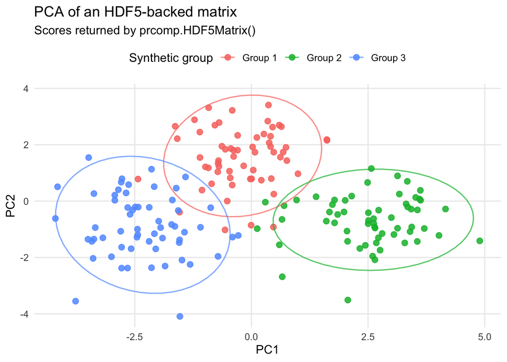

Figure 1: PCA scores computed from an HDF5-backed matrix

```r
class(pca_h5$x)
[1] "HDF5Matrix" "HDF5Matrix" "R6"
dim(pca_h5$x)
[1] 180  40

pca_scores <- as.matrix(pca_h5$x[, 1:2])
pca_df <- data.frame(
  PC1 = pca_scores[, 1],
  PC2 = pca_scores[, 2],
  group = group
)

if (requireNamespace("ggplot2", quietly = TRUE)) {
  ggplot2::ggplot(pca_df, ggplot2::aes(PC1, PC2, colour = group)) +
    ggplot2::geom_point(size = 2.4, alpha = 0.85) +
    ggplot2::stat_ellipse(linewidth = 0.6, alpha = 0.7) +
    ggplot2::theme_minimal(base_size = 12) +
    ggplot2::theme(
      legend.position = "top",
      panel.grid.minor = ggplot2::element_blank()
    ) +
    ggplot2::labs(
      title = "PCA of an HDF5-backed matrix",
      subtitle = "Scores returned by prcomp.HDF5Matrix()",
      x = "PC1",
      y = "PC2",
      colour = "Synthetic group"
    )
} else {
  plot(
    pca_df$PC1,
    pca_df$PC2,
    pch = 19,
    xlab = "PC1",
    ylab = "PC2",
    main = "PCA of an HDF5-backed matrix"
  )
}
```

## 8.3 QR decomposition

The QR decomposition returns HDF5-backed `Q` and `R` matrices. The argument `thin` controls whether a reduced decomposition is returned. With `thin = TRUE`, `Q` has only the columns needed to reconstruct the input matrix, which is usually preferable for tall matrices because it avoids storing unnecessary columns. With `thin = FALSE`, a full `Q` matrix is returned.

Rather than comparing the signs of individual columns, the example validates the factorization and the orthogonality of `Q`.

```r
QR_h5 <- qr(A_h5, thin = TRUE, overwrite = TRUE)

Q <- as.matrix(QR_h5$Q)
R <- as.matrix(QR_h5$R)

all.equal(Q %*% R, A, tolerance = 1e-6)
[1] TRUE
all.equal(crossprod(Q), diag(ncol(Q)), tolerance = 1e-6)
[1] TRUE
```

For tall-skinny matrices, the QR method can use the TSQR path. The `method = "auto"` setting selects the backend according to the matrix shape, while `method = "tsqr"` requests the tall-skinny algorithm explicitly.

```r
X_tsqr <- matrix(rnorm(600 * 30), nrow = 600, ncol = 30)
X_tsqr_h5 <- hdf5_create_matrix(
  h5file,
  "decomp/X_tsqr",
  data = X_tsqr,
  overwrite = TRUE
)

QR_tsqr_h5 <- qr(
  X_tsqr_h5,
  thin = TRUE,
  method = "tsqr",
  threads = 2L,
  overwrite = TRUE
)

dim(QR_tsqr_h5$Q)
[1] 600  30
dim(QR_tsqr_h5$R)
[1] 30 30
```

## 8.4 Cholesky decomposition and inverse

For symmetric positive-definite matrices, `chol()` and `solve()` can be used directly on `HDF5Matrix` objects.

```r
set.seed(321)
Z <- matrix(rnorm(200 * 50), nrow = 200, ncol = 50)
SPD <- crossprod(Z) + diag(1e-6, 50)

SPD_h5 <- hdf5_create_matrix(
  h5file,
  "decomp/SPD",
  data = SPD,
  overwrite = TRUE
)

Ch_h5 <- chol(SPD_h5, overwrite = TRUE)
Inv_h5 <- solve(SPD_h5, overwrite = TRUE)

Ch <- as.matrix(Ch_h5)
chol_error <- min(
  max(abs(crossprod(Ch) - SPD)),
  max(abs(tcrossprod(Ch) - SPD))
)
chol_error < 1e-6
[1] TRUE

all.equal(as.matrix(Inv_h5), solve(SPD), tolerance = 1e-6)
[1] TRUE
```

## 8.5 Eigen decomposition and pseudoinverse

Additional decompositions are available through S3 methods. For example, `eigen()` can be applied to symmetric HDF5-backed matrices, and `pseudoinverse()` computes the Moore–Penrose pseudoinverse.

```r
Eig_h5 <- eigen(
  SPD_h5,
  symmetric = TRUE,
  k = 5L,
  overwrite = TRUE
)

head(Eig_h5$values)
[1] 430.0639 406.9944 392.0909 374.7714 365.4983
dim(Eig_h5$vectors)
[1] 50  5

Pinv_h5 <- pseudoinverse(
  A_h5,
  overwrite = TRUE
)

dim(Pinv_h5)
[1]  80 300
```

# 9 Dataset operations: split, reduce, and apply

## 9.1 Split

`split()` divides an `HDF5Matrix` into equal-sized blocks stored as separate datasets in the same HDF5 file. Use `n_blocks` to specify the number of blocks, or `block_size` to specify the maximum number of rows (or columns, if `bycols = TRUE`) per block.

```r
fn     <- tempfile(fileext = ".h5")
X      <- hdf5_create_matrix(fn, "data/X", data = matrix(rnorm(600), 60, 10))
blocks <- split(X, n_blocks = 3)   # returns a named list: block_0, block_1, block_2
dim(blocks[["block_0"]])           # 20 x 10
lapply(blocks, close)
close(X)
hdf5_close_all()
unlink(fn)
```

`split_dataset()` is an equivalent with a cleaner signature that omits the `f` and `drop` parameters inherited from `base::split`. Both produce identical results.

Note: `BigDataStatMeth::split()` produces an error because `split` is a `base` generic — this is the same behaviour as `BigDataStatMeth::cor()` or `BigDataStatMeth::svd()`. The correct call is simply `split(X, n_blocks = 3)` after loading the package.

## 9.2 Reduce

`reduce()` accumulates all datasets in the same HDF5 group as `x` into a single dataset using `"+"` or `"-"`. This is useful after a split operation or when partial results from parallel computation are stored as separate datasets in a group.

```r
fn <- tempfile(fileext = ".h5")
hdf5_create_matrix(fn, "parts/A", data = matrix(1:12, 3, 4))
hdf5_create_matrix(fn, "parts/B", data = matrix(1:12, 3, 4))
hdf5_create_matrix(fn, "parts/C", data = matrix(1:12, 3, 4))

entry  <- hdf5_matrix(fn, "parts/A")
result <- reduce(entry, func = "+")   # sums A + B + C
as.matrix(result)                     # each element equals 3x the original
hdf5_close_all()
unlink(fn)
```

`hdf5_reduce(filename, group, ...)` provides the same operation when you only have the file path and group name, without needing an open `HDF5Matrix` object.

## 9.3 Apply function

`apply_function()` applies a predefined algebraic or statistical operation to a named set of datasets within the HDF5 group of `x`.

**This is not equivalent to `base::apply()`.** It does not apply an arbitrary R function row- or column-wise. Instead, it dispatches built-in C++ operations — QR decomposition, cross-products, Cholesky, and others — to a batch of datasets in the file. Support for row/column-wise application of arbitrary R functions (`apply.HDF5Matrix`) is planned for a future release.

```r
fn <- tempfile(fileext = ".h5")
hdf5_create_matrix(fn, "data/A", data = matrix(rnorm(50), 5, 10))
hdf5_create_matrix(fn, "data/B", data = matrix(rnorm(50), 5, 10))

X   <- hdf5_matrix(fn, "data/A")
res <- apply_function(X, datasets = c("A", "B"),
                      func = "CrossProd", out_group = "RESULTS")
hdf5_close_all()
unlink(fn)
```

`hdf5_apply(filename, group, datasets, func, outgroup, ...)` provides the same operation when you only have the file path, without an open object.

# 10 Compression and HDF5 file space management

## 10.1 Compression

HDF5 datasets can be stored with different compression levels. Lower compression levels generally reduce writing time but use more disk space. Higher compression levels may reduce file size but can increase the time needed to write and read data. The default value in `BigDataStatMeth` is `compression = 6`, which provides a balanced setting for many workflows.

The following small example illustrates the trade-off between writing time and file size. It is not intended as a formal benchmark.

```r
set.seed(123)
X_cmp <- round(matrix(rnorm(2500 * 250), nrow = 2500, ncol = 250), 2)

f0 <- tempfile(fileext = ".h5")
f6 <- tempfile(fileext = ".h5")

t0 <- system.time(
  hdf5_create_matrix(
    f0, "data/X",
    data = X_cmp,
    compression = 0,
    overwrite = TRUE
  )
)

t6 <- system.time(
  hdf5_create_matrix(
    f6, "data/X",
    data = X_cmp,
    compression = 6,
    overwrite = TRUE
  )
)

data.frame(
  compression = c(0, 6),
  elapsed = c(t0[["elapsed"]], t6[["elapsed"]]),
  file_size_MB = round(file.info(c(f0, f6))$size / 1024^2, 3)
)
  compression elapsed file_size_MB
1           0   0.002        4.771
2           6   0.167        1.151
```

Formal performance comparisons should be run on the target hardware and with representative datasets.

## 10.2 HDF5 file space management

When datasets are deleted or overwritten in an HDF5 file, the physical file size on disk does not always decrease immediately. `BigDataStatMeth` creates HDF5 files using a file space management strategy that allows free space inside the file to be tracked and reused by subsequent writes. Thus, space released by removed datasets can be reused within the same file instead of unnecessarily increasing the file size after repeated operations.

This behavior helps control file growth during workflows that create, overwrite, or remove intermediate datasets. Nevertheless, reducing the physical size of an existing HDF5 file may require repacking the file. The HDF Group provides external command-line tools for this purpose. In particular, the [`h5repack` user guide](https://support.hdfgroup.org/documentation/hdf5/latest/_h5_t_o_o_l__r_p__u_g.html) describes how to rewrite an HDF5 file into a new compacted or reconfigured file. This is an external HDF5 utility and is not executed from this vignette.

# 11 Managing HDF5 resources

HDF5-backed objects keep file handles open while they are in use. In ordinary interactive workflows these handles are released when objects are garbage-collected. Users can also close objects explicitly.

```r
close(X_h5_reopened)
```

The function `hdf5_close_all()` closes the HDF5 handles currently tracked by the package, including open file handles. After this call, HDF5-backed objects that pointed to those handles should be reopened before further use.

Calling `gc()` may help trigger R finalizers for objects that are no longer referenced, which can be useful when repeatedly re-running code during development.

```r
hdf5matrix_options(
  paral = old_opts$paral,
  block_size = old_opts$block_size,
  threads = old_opts$threads,
  compression = old_opts$compression
)

hdf5_close_all()
gc()
          used (Mb) gc trigger  (Mb) limit (Mb) max used  (Mb)
Ncells 1616321 86.4    2818887 150.6         NA  2818887 150.6
Vcells 3728117 28.5    8388608  64.0      36864  5295394  40.5
```

# 12 Extending BigDataStatMeth through C++

The examples above use the standard R interface, which is the recommended entry point for most users. However, `BigDataStatMeth` also provides a C++ infrastructure for developers who need to implement new scalable methods.

Internally, the package defines C++ classes for managing HDF5 files, groups, and datasets, together with block-wise routines for linear algebra and statistical operations. These are the same computational building blocks used by the R/S3 interface. As a result, developers can reuse the package infrastructure from Rcpp-based code instead of implementing HDF5 file management, block iteration, and numerical operations from scratch.

This makes the package useful not only as an end-user R package, but also as a development framework for extending HDF5-backed statistical computing in C++. Since the purpose of this vignette is to introduce the standard R interface, the C++ API is not discussed in detail here. Nevertheless, it is an important part of the package architecture and provides the computational infrastructure behind the R/S3 methods shown above.

# 13 Session information

```r
sessionInfo()
R version 4.5.3 (2026-03-11)
Platform: aarch64-apple-darwin20
Running under: macOS Tahoe 26.6.2

Matrix products: default
BLAS:   /Library/Frameworks/R.framework/Versions/4.5-arm64/Resources/lib/libRblas.0.dylib
LAPACK: /Library/Frameworks/R.framework/Versions/4.5-arm64/Resources/lib/libRlapack.dylib;  LAPACK version 3.12.1

locale:
[1] C/en_US.UTF-8/en_US.UTF-8/C/en_US.UTF-8/en_US.UTF-8

time zone: Europe/Madrid
tzcode source: internal

attached base packages:
[1] stats     graphics  grDevices utils     datasets  methods   base

other attached packages:
[1] BigDataStatMeth_2.0.6 knitr_1.50            BiocStyle_2.36.0

loaded via a namespace (and not attached):
 [1] gtable_0.3.6        jsonlite_2.0.0      dplyr_1.2.1
 [4] compiler_4.5.3      BiocManager_1.30.27 tidyselect_1.2.1
 [7] Rcpp_1.1.2          bitops_1.0-9        dichromat_2.0-0.1
[10] jquerylib_0.1.4     scales_1.4.0        yaml_2.3.12
[13] fastmap_1.2.0       ggplot2_4.0.1       R6_2.6.1
[16] labeling_0.4.3      generics_0.1.4      MASS_7.3-65
[19] tibble_3.3.1        bookdown_0.43       bslib_0.9.0
[22] pillar_1.11.1       RColorBrewer_1.1-3  rlang_1.3.0
[25] cachem_1.1.0        xfun_0.52           sass_0.4.10
[28] S7_0.2.1            cli_3.6.6           withr_3.0.3
[31] magrittr_2.0.5      digest_0.6.39       grid_4.5.3
[34] rstudioapi_0.17.1   lifecycle_1.0.5     vctrs_0.7.3
[37] evaluate_1.0.4      glue_1.8.1          data.table_1.18.4
[40] farver_2.1.2        RCurl_1.98-1.19     rmarkdown_2.29
[43] tools_4.5.3         pkgconfig_2.0.3     htmltools_0.5.8.1
```